# EPIC ISF MMSD School Climate Analyses — Staff

EPIC Research Team

Thursday, May 07, 2026 09:43 PM

# 1 Overview

This notebook analyzes MMSD **staff** school climate survey data using exploratory and confirmatory factor analysis (CFA), followed by a descriptive analysis of validated factor scores across schools and school years. The analysis is restricted to respondents with `secondary_survey_population == "Staff"` and uses the 58 items administered in both the Fall and Spring waves.

## 1.1 Study context and ISF program framing

The data span three school years: **2022–23** (pre-program baseline), **2023–24**, and **2024–25** (ISF implementation years). The ISF program was introduced starting in 2023–24. The descriptive section examines how staff climate perceptions changed across these years, both overall and by school, to characterize the program context from the staff perspective. Staff perceptions are especially valuable as a complement to student data – convergence or divergence between the two populations is itself an informative finding.

## Item structure

| Wave | N items | Notes |
| --- | --- | --- |
| Both Fall and Spring | 58 | Used in pooled analysis |
| Fall only | 4 | q325–q328; excluded pending coverage confirmation |
| Spring only | 0 | None |

## Analysis stages

1. Data import, cleaning, and scoring
2. Item coverage audit
3. Missing data examination
4. Descriptive analyses (item-level)
5. Build pooled dataset
6. Split-sample feasibility
7. Reliability screening
8. Factorability checks (KMO, Bartlett, VSS)
9. Exploratory Factor Analysis (EFA)
10. Item retention
11. Confirmatory Factor Analysis (CFA) with FIML
12. Final theory-guided CFA model
13. Factor score extraction
14. Descriptive summaries of factor scores
15. ISF context: school-year descriptive trends

# 2 Data Import, Cleaning, and Scoring

# 3 Item Coverage Audit

**Note on Fall-only items (q325–q328).** These four items measure “Respect for Students” and have direct both-wave parallels in q371–q374, which use nearly identical wording and are included in the pooled analysis. Unless MMSD confirms that q325–q328 reached the full Fall staff sample, a Fall-only staff analysis cannot be attempted with these items.

# 4 Missing Data Examination

# 5 Descriptive Analyses

**Interpretation.** Staff response means reflect perceptions of student and school climate from the perspective of school adults. Note that items in the Teasing_Bullying dimension are negatively valenced – higher scores indicate more perceived bullying and teasing, which is substantively opposite to the direction of most other items. Dimension-level means and Fall–Spring comparisons provide a preliminary view of whether staff perceptions differ across administrations or school years.

# 6 Build Pooled Dataset

# 7 Split-Sample Feasibility

# 8 Reliability Screening

**Interpretation.** Internal consistency estimates guide item selection for the EFA and CFA. Most of the district’s theoretically defined staff scales show strong or acceptable reliability, reflecting that staff survey items within each dimension tend to measure coherent constructs. Scales with $\alpha < .60$ or average inter-item correlations below .20 suggest that the district’s theoretical grouping does not correspond well to empirical factor structure for those dimensions, and EFA loadings should be examined before assigning those items to a factor. Single-item dimensions (Wellbeing q299, Value at Work q302, Facilities q366) cannot be evaluated for reliability and will be assessed by their EFA loading patterns – items that load onto a larger empirical factor may be retained as part of that factor even if they originated from a single-item theoretical scale.

# 9 Exploratory Factor Analysis (EFA)

EFA is conducted using pairwise-complete polychoric correlations from the EFA subsample – specifically, median imputation is applied to the item matrix before polychoric estimation, which is used only for the parallel analysis and factor grid steps and has no effect on CFA or descriptive results. Oblimin rotation allows factors to correlate, which is appropriate for school climate constructs. True FIML is applied at the CFA stage. The number of factors to extract is guided by parallel analysis, with additional consideration of theoretical interpretability and the practical requirement that extracted factors map onto interpretable constructs.

## 9.1 Factorability Checks

Before running the EFA, three standard diagnostics confirm that the staff item correlation matrix contains enough shared variance to support factor analysis. All three use the same imputed item matrix and polychoric correlation matrix, which are computed once here and reused throughout the EFA section.

### 9.1.1 Kaiser-Meyer-Olkin (KMO) Measure of Sampling Adequacy

📋 KMO Results and Interpretation

The overall KMO MSA is **0.626**, which falls in Kaiser’s **“mediocre”** range (.60 – .69). This is lower than the ≥ .70 threshold typically recommended before proceeding with EFA, and well below the .80+ values common in well-designed survey batteries. The mediocre MSA is a direct consequence of the structural features of this dataset: a small staff sample (n = 221 rows across all administrations), 58 items spanning a wide range of loosely related school climate domains, and several near-isolate items (Facilities q366, Wellbeing q299, Value at Work q302) that share limited variance with any coherent item cluster. The overall MSA does not disqualify EFA here – the theoretical rationale for the staff climate constructs is strong and the Bartlett test (below) confirms the items are far from uncorrelated – but it does provide empirical context for why some factors emerge weakly and why item retention decisions must be made carefully.

**Per-item MSA flags.** One item falls below the .50 threshold warranting serious consideration for removal prior to EFA:

- **q313** (MSA = 0.405) – Safety/Belonging item. This is the weakest item in the battery by a notable margin and is a strong removal candidate independent of EFA loading quality.

Three additional items fall in the .43 – .49 range and warrant close monitoring during item retention:

- **q359** (0.434) – Fairness
- **q356** (0.444) – Fairness (already dropped for cross-loading in the current retention step)
- **q318** (0.479) – Student Engagement

The remaining items range from .52 to .76, with the highest MSA values concentrated among Student Engagement (q314, q315) and Adult Collegiality items – which are also the most psychometrically cohesive subscales in the reliability screening. **Downstream action:** q313’s MSA of 0.405 should be flagged in the item retention chunk and treated as an additional drop candidate; see updated notes there.

### 9.1.2 Bartlett’s Test of Sphericity

📋 Bartlett’s Test Results and Interpretation

Bartlett’s test is highly significant: $\chi^2$(1653) = 55,513.33, *p* < .001. The null hypothesis that the polychoric correlation matrix is an identity matrix is decisively rejected. The items are far from uncorrelated, and there is clearly shared variance available for factor extraction. **This is the expected result** for a multi-domain school climate battery and functions as a data-integrity confirmation rather than a meaningful diagnostic – the large chi-square is partially an artifact of estimating Bartlett’s statistic from a 58 x 58 polychoric matrix with 221 observations (1,653 degrees of freedom). No action is required on the basis of this result. Proceed to KMO and VSS for the substantive factorability evidence.

### 9.1.3 Very Simple Structure (VSS) Criterion

📋 VSS and MAP Results and Interpretation

The three criteria tell a divergent story that is worth unpacking:

| Criterion | Suggested *k* | Value |
| --- | --- | --- |
| VSS complexity-1 peak | **1** | 0.845 |
| VSS complexity-2 peak | **2** | 0.770 |
| MAP minimum | **9** | 0.0257 |
| BIC minimum (across 1–10) | **10** | 36,769.5 |
| Parallel analysis | **9** | – |

**VSS complexity-1 (peak at 1 factor, c1 = 0.845):** The single-factor solution achieves the best fit under a strict one-loading-per-item constraint. This is the classic signature of a large general factor – in this case, a broad “positive school climate” dimension that saturates most items. It does not mean a 1-factor model is adequate; it means that a single dominant variance component runs through the item pool. This general factor effect is common in school climate surveys and is one reason the overall KMO is in the mediocre range: many items correlate with each other primarily through this general factor rather than through tighter subscale-specific variance.

**VSS complexity-2 (peak at 2 factors, c2 = 0.770):** When items are allowed to load on up to two factors, the best simple-structure solution uses only 2. This is another under-extraction signal driven by the general factor – the VSS complexity-2 criterion is picking up the general factor plus one major split (likely positive vs. negative valence, given the Teasing/Bullying items). Both VSS values are products of this structural feature and should not be taken as meaningful factor count recommendations.

**MAP minimum at 9 factors (MAP = 0.0257):** MAP is the most credible criterion here because it directly tests when residual common variance is exhausted. It recommends 9 factors, which aligns exactly with parallel analysis and is consistent with the theory-guided 9-factor CFA structure. The MAP value is nearly identical at 9 (0.0257) and 10 (0.0261), suggesting the 9th factor captures genuine variance while the 10th adds noise. **This is the key convergence point: MAP = 9, parallel analysis = 9, theory = 9.**

**BIC minimum at 10:** BIC continues to decline through the full grid (42,039 at F1 down to 36,770 at F10), favoring more factors. This monotone decline is expected given the small item-to-respondent ratio – BIC does not penalize over-extraction as strongly as MAP at these sample sizes.

**Bottom line:** The VSS complexity values are driven by a dominant general factor in the item pool and should be disregarded for factor count selection in this case. MAP at 9 and parallel analysis at 9 are the operative empirical guidelines, and they align with the theory-guided 9-factor CFA structure. No change to the planned factor solution is warranted.

## 9.2 Parallel Analysis

**Interpretation.** Parallel analysis suggested retaining **9 factors**, which aligns with MAP (also 9) and the theory-guided 9-factor CFA structure. This convergence across two independent empirical criteria (MAP and parallel analysis) provides solid justification for the 9-factor solution. As noted in the VSS/MAP callout above, the VSS complexity values (c1 peak at 1, c2 peak at 2) are artifacts of a dominant general climate factor running through the item pool and do not represent actionable factor count guidance here. The BIC-minimizing F10 EFA solution is used as the screening tool for item retention because it provides the most granular look at item behavior, but the final reported CFA is the 9-factor theory-guided model.

## 9.3 EFA Helper Functions

## 9.4 Fit Model Grid

## 9.5 Compare Candidate Solutions

**Interpretation.** The fit comparison table shows TLI, RMSEA, BIC, variance explained, and item quality statistics across solutions F5–F10. The auto-selected solution (F10 by BIC) provided the best empirical fit in this model grid, so it is used as the screening solution for the next step. That does not mean the 10-factor EFA is the final reporting structure. In this notebook, the EFA is used to identify weak or cross-loading items and to understand how the staff items cluster empirically, while the final reported model is the theory-guided CFA built around interpretable staff climate domains aligned with the ISF framework. Extra EFA factors beyond the core staff domains likely reflect narrow phrasing bundles or local dependencies rather than broad constructs worth reporting on their own.

## 9.6 Select and Inspect Final EFA Solution

**Interpretation.** The selected EFA solution is used to identify the staff items that behave cleanly versus those that show weak anchoring or substantial overlap across factors. The loading matrix gives the item-level evidence, while the Phi matrix shows how strongly the exploratory factors relate to one another. In the staff survey, some empirical factors blend closely related domains such as discipline, fairness, and aspects of collegial climate. That blending is informative, but it is not by itself a reason to collapse those constructs in the final CFA, because the confirmatory stage is meant to test a cleaner, more interpretable measurement structure.

## 9.7 Primary Loading Table

# 10 Item Retention

# 11 Draft CFA Structure from EFA

**Interpretation.** The EFA-derived syntax is included as a diagnostic checkpoint, not as the final substantive model. In the staff data, the exploratory grouping can mix items from nearby content domains when those domains are highly correlated in practice. That is useful evidence about the empirical structure, but the theory-guided CFA that follows is more defensible for reporting because it restores interpretable factor labels and tests whether those planned constructs can still fit the observed data adequately.

# 12 CFA Helper Functions

# 13 Initial EFA-Derived CFA (Sanity Check)

**Interpretation.** The EFA-derived CFA is used as a sanity check to confirm that the retained staff item set can support a converged latent model before imposing the theory-guided structure. Acceptable convergence here suggests the item pool is workable. It does not mean the EFA-derived factor labels are the best reporting solution; it simply shows that the retained items contain enough structure to move into the confirmatory stage.

# 14 Final Theory-Guided CFA Model Comparison

The final confirmatory stage compares two theory-guided staff CFA specifications that both respect the EFA screening results. The first is an 8-factor model that keeps q371–q374 inside PeerRelations. The second is a 9-factor model that separates those items into a distinct StudentAdultRespect factor, which is both more interpretable substantively and more faithful to the district item content. Both models use the EFA-pruned item pool, so the comparison focuses on whether the respect items are better treated as their own latent construct.

```r
# ============================================================
# Theory-guided CFA model comparison
# ------------------------------------------------------------
# Both candidate models use the EFA-pruned item set:
#   dropped for weak/cross-loading = q314, q315, q334, q335,
#   q356, q361
#
# Model 1 (8 factors): keeps q371-q374 inside PeerRelations
# Model 2 (9 factors): splits q371-q374 into StudentAdultRespect
# ============================================================

cfa_items_pruned <- c(
  "q336","q337","q338","q339","q340","q341",
  "q316","q317","q318","q319","q320",
  "q321","q322","q323","q324",
  "q371","q372","q373","q374",
  "q342","q343","q344","q345","q346","q347","q348",
  "q349","q350","q351","q352","q353","q354",
  "q355","q357","q358","q359","q360",
  "q362","q363","q364","q365",
  "q329","q330","q331","q332","q333"
)

cfa_model_8factor <- "
F_Collegiality      =~ q336 + q337 + q338 + q339 + q340 + q341
F_StudentEngagement =~ q316 + q317 + q318 + q319 + q320
F_PeerRelations     =~ q321 + q322 + q323 + q324 + q371 + q372 + q373 + q374
F_TeasingBullying   =~ q342 + q343 + q344 + q345 + q346 + q347 + q348
F_Discipline        =~ q349 + q350 + q351 + q352 + q353 + q354
F_Fairness          =~ q355 + q357 + q358 + q359 + q360
F_Families          =~ q362 + q363 + q364 + q365
F_SeekHelp          =~ q329 + q330 + q331 + q332 + q333
"

cfa_model_9factor <- "
F_Collegiality        =~ q336 + q337 + q338 + q339 + q340 + q341
F_StudentEngagement   =~ q316 + q317 + q318 + q319 + q320
F_PeerRelations       =~ q321 + q322 + q323 + q324
F_StudentAdultRespect =~ q371 + q372 + q373 + q374
F_TeasingBullying     =~ q342 + q343 + q344 + q345 + q346 + q347 + q348
F_Discipline          =~ q349 + q350 + q351 + q352 + q353 + q354
F_Fairness            =~ q355 + q357 + q358 + q359 + q360
F_Families            =~ q362 + q363 + q364 + q365
F_SeekHelp            =~ q329 + q330 + q331 + q332 + q333
"

cat("8-factor model:
")
```

```
8-factor model:
```

```r
cat(cfa_model_8factor)
```

```
F_Collegiality      =~ q336 + q337 + q338 + q339 + q340 + q341
F_StudentEngagement =~ q316 + q317 + q318 + q319 + q320
F_PeerRelations     =~ q321 + q322 + q323 + q324 + q371 + q372 + q373 + q374
F_TeasingBullying   =~ q342 + q343 + q344 + q345 + q346 + q347 + q348
F_Discipline        =~ q349 + q350 + q351 + q352 + q353 + q354
F_Fairness          =~ q355 + q357 + q358 + q359 + q360
F_Families          =~ q362 + q363 + q364 + q365
F_SeekHelp          =~ q329 + q330 + q331 + q332 + q333
```

```r
cat("
9-factor model:
")
```

```
9-factor model:
```

```r
cat(cfa_model_9factor)
```

```
F_Collegiality        =~ q336 + q337 + q338 + q339 + q340 + q341
F_StudentEngagement   =~ q316 + q317 + q318 + q319 + q320
F_PeerRelations       =~ q321 + q322 + q323 + q324
F_StudentAdultRespect =~ q371 + q372 + q373 + q374
F_TeasingBullying     =~ q342 + q343 + q344 + q345 + q346 + q347 + q348
F_Discipline          =~ q349 + q350 + q351 + q352 + q353 + q354
F_Fairness            =~ q355 + q357 + q358 + q359 + q360
F_Families            =~ q362 + q363 + q364 + q365
F_SeekHelp            =~ q329 + q330 + q331 + q332 + q333
```

```r
cfa_fit_8factor <- fit_cfa_fiml(cfa_model_8factor, cfa_data, cfa_items_pruned)
cfa_fit_9factor <- fit_cfa_fiml(cfa_model_9factor, cfa_data, cfa_items_pruned)

fit_8factor <- safe_extract_fit(cfa_fit_8factor, "Staff theory-guided CFA (8-factor)")
fit_9factor <- safe_extract_fit(cfa_fit_9factor, "Staff theory-guided CFA (9-factor)")

bind_rows(fit_8factor, fit_9factor)
```

| model | converged | chisq | df | cfi | tli | rmsea | srmr |
| --- | --- | --- | --- | --- | --- | --- | --- |
| Staff theory-guided CFA (8-factor) | TRUE | 2526.939 | 961 | 0.768 | 0.750 | 0.086 | 0.117 |
| Staff theory-guided CFA (9-factor) | TRUE | 2219.708 | 953 | 0.813 | 0.796 | 0.078 | 0.097 |

```r
cfa_model_comparison <- bind_rows(
  fit_8factor %>% mutate(model = "8-factor"),
  fit_9factor %>% mutate(model = "9-factor")
) %>%
  select(model, chisq, df, cfi, tli, rmsea, srmr)

cfa_model_comparison
```

| model | chisq | df | cfi | tli | rmsea | srmr |
| --- | --- | --- | --- | --- | --- | --- |
| 8-factor | 2526.939 | 961 | 0.768 | 0.750 | 0.086 | 0.117 |
| 9-factor | 2219.708 | 953 | 0.813 | 0.796 | 0.078 | 0.097 |

```r
cfa_comparison_deltas <- tibble(
  metric = c("cfi", "tli", "rmsea", "srmr"),
  `8-factor` = c(
    fitMeasures(cfa_fit_8factor, "cfi"),
    fitMeasures(cfa_fit_8factor, "tli"),
    fitMeasures(cfa_fit_8factor, "rmsea"),
    fitMeasures(cfa_fit_8factor, "srmr")
  ),
  `9-factor` = c(
    fitMeasures(cfa_fit_9factor, "cfi"),
    fitMeasures(cfa_fit_9factor, "tli"),
    fitMeasures(cfa_fit_9factor, "rmsea"),
    fitMeasures(cfa_fit_9factor, "srmr")
  )
) %>%
  mutate(diff_9_minus_8 = `9-factor` - `8-factor`) %>%
  mutate(across(where(is.numeric), ~ round(.x, 3)))

cfa_comparison_deltas
```

| metric | 8-factor | 9-factor | diff_9_minus_8 |
| --- | --- | --- | --- |
| cfi | 0.768 | 0.813 | 0.044 |
| tli | 0.750 | 0.796 | 0.046 |
| rmsea | 0.086 | 0.078 | -0.008 |
| srmr | 0.117 | 0.097 | -0.020 |

**Interpretation.** The two CFA candidates are estimated on the same pruned staff item set, making this a direct test of whether q371–q374 should stay inside PeerRelations or be modeled as a distinct StudentAdultRespect factor. The 9-factor solution is preferred when it improves global fit and yields a cleaner substantive mapping of those four items.

# 15 Final CFA Selected for Scoring and Plots

The 9-factor model is used as the final reported model for the remainder of the notebook. This means all downstream factor-score extraction, summaries, and plots are based on the specification that treats q371–q374 as StudentAdultRespect.

```r
cfa_fit_final   <- cfa_fit_9factor
cfa_model_final <- cfa_model_9factor
cfa_items_final <- cfa_items_pruned

safe_extract_fit(cfa_fit_final, "Staff final theory-guided CFA (selected 9-factor model)")
```

| model | converged | chisq | df | cfi | tli | rmsea | srmr |
| --- | --- | --- | --- | --- | --- | --- | --- |
| Staff final theory-guided CFA (selected 9-factor model) | TRUE | 2219.708 | 953 | 0.813 | 0.796 | 0.078 | 0.097 |

```r
std_final <- get_std_loadings(cfa_fit_final)

cat("Final model standardized loadings:
")
```

```
Final model standardized loadings:
```

```r
std_final
```

| factor | item | est | std_loading | weak_loading |
| --- | --- | --- | --- | --- |
| F_Collegiality | q337 | 0.734 | 0.914 | FALSE |
| F_Collegiality | q338 | 0.641 | 0.868 | FALSE |
| F_Collegiality | q336 | 0.579 | 0.842 | FALSE |
| F_Collegiality | q339 | 0.575 | 0.792 | FALSE |
| F_Collegiality | q341 | 0.489 | 0.733 | FALSE |
| F_Collegiality | q340 | 0.627 | 0.687 | FALSE |
| F_Discipline | q351 | 0.682 | 0.878 | FALSE |
| F_Discipline | q350 | 0.700 | 0.799 | FALSE |
| F_Discipline | q352 | 0.610 | 0.746 | FALSE |
| F_Discipline | q353 | 0.588 | 0.695 | FALSE |

[output cut: 36 more lines]

```r
cat("
Indicators with standardized loading < .40:
")
```

```
Indicators with standardized loading < .40:
```

```r
std_final %>% filter(weak_loading)
```

| factor | item | est | std_loading | weak_loading |
| --- | --- | --- | --- | --- |
| F_Discipline | q354 | -0.617 | -0.676 | TRUE |

```r
cat("Top modification indices for the final model (MI >= 10):
")
```

```
Top modification indices for the final model (MI >= 10):
```

```r
get_modindices(cfa_fit_final)
```

| parameter | mi | epc | sepc.all |
| --- | --- | --- | --- |
| q359 ~~ q360 | 149.06824 | 0.14291925 | 0.9889956 |
| F_Discipline =~ q355 | 95.63337 | 0.54085881 | 0.6906128 |
| F_Discipline =~ q340 | 55.27779 | 0.43281905 | 0.4739093 |
| F_StudentEngagement =~ q355 | 53.50614 | 0.41698577 | 0.5324416 |
| F_Discipline =~ q319 | 48.32551 | 0.54608801 | 0.6784529 |
| F_Discipline =~ q348 | 46.98541 | -0.34116060 | -0.4232996 |
| F_StudentEngagement =~ q348 | 46.35202 | -0.34098536 | -0.4230822 |
| F_PeerRelations =~ q348 | 44.64757 | -0.34240553 | -0.4248443 |
| q357 ~~ q358 | 36.08238 | 0.13403153 | 0.9348797 |
| q317 ~~ q318 | 34.39404 | 0.12069035 | 0.4577385 |

[output cut: 65 more lines]

# 16 Latent Factor Correlations

```r
lavInspect(cfa_fit_final, "cor.lv") %>% round(3)
```

```
                      F_Cllg F_StdE F_PrRl F_StAR F_TsnB F_Dscp F_Frns F_Fmls F_SkHl
F_Collegiality         1.000
F_StudentEngagement    0.527  1.000
F_PeerRelations        0.405  0.829  1.000
F_StudentAdultRespect  0.550  0.173  0.227  1.000
F_TeasingBullying     -0.364 -0.338 -0.425 -0.318  1.000
F_Discipline           0.499  0.713  0.591  0.171 -0.377  1.000
F_Fairness             0.513  0.375  0.345  0.448 -0.395  0.365  1.000
F_Families             0.557  0.311  0.211  0.541 -0.283  0.299  0.559  1.000
F_SeekHelp             0.688  0.524  0.444  0.435 -0.326  0.501  0.599  0.507  1.000
```

**Interpretation.** The final staff CFA is interpreted as a 9-factor model, including a distinct StudentAdultRespect factor. The latent correlation matrix should therefore be read as a test of whether the respect construct is related to, but empirically separable from, PeerRelations and the other staff climate domains.

# 17 Extract Factor Scores

```r
case_idx     <- as.integer(lavInspect(cfa_fit_final, "case.idx"))
scores_final <- lavPredict(cfa_fit_final, type = "lv") %>% as_tibble()
factor_names <- names(scores_final)

cat("Sliced rows:", length(case_idx), "\n")
```

```
Sliced rows: 221
```

```r
cat("Score rows: ", nrow(scores_final), "\n")
```

```
Score rows:  221
```

```r
stopifnot(length(case_idx) == nrow(scores_final))

cfa_data_scored <- cfa_data %>%
  slice(case_idx) %>%
  bind_cols(scores_final)

dupe_check <- cfa_data_scored %>%
  count(staff_id, school_year, iteration) %>%
  filter(n > 1)

cat("Duplicate rows in scored output:", nrow(dupe_check), "\n")
```

```
Duplicate rows in scored output: 0
```

```r
cfa_data_scored %>%
  select(staff_id, school_year, iteration, all_of(factor_names)) %>%
  head()
```

| staff_id | school_year | iteration | F_Collegiality | F_StudentEngagement | F_PeerRelations | F_StudentAdultRespect | F_TeasingBullying | F_Discipline | F_Fairness | F_Families | F_SeekHelp |
| --- | --- | --- | --- | --- | --- | --- | --- | --- | --- | --- | --- |
| 173350 | 2022-2023 | Fall | -0.09407966 | 0.53890467 | 1.4802855 | 0.28375823 | -0.7823132 | -0.6880827 | 0.05021962 | 0.07554082 | -1.93385743 |
| 173361 | 2022-2023 | Fall | 0.17199352 | -0.09268876 | -0.1740316 | 0.01309381 | 0.6681201 | -0.4959303 | -0.29160522 | -0.05285553 | -0.04960823 |
| 173372 | 2022-2023 | Fall | -2.56369089 | -2.00685330 | -2.1690740 | -1.31918853 | 0.6855071 | 0.6218462 | 0.01466539 | -0.53071036 | -2.75091670 |
| 173467 | 2022-2023 | Fall | 0.21160950 | 0.39123519 | 1.0025546 | 0.34001735 | -0.7075397 | -0.1363589 | 0.29880079 | -0.01801938 | 0.25895750 |
| 173487 | 2022-2023 | Fall | 0.09673754 | -1.40490561 | -1.2539563 | -0.18630745 | 0.5328040 | -1.2617581 | -0.81929682 | -1.38570513 | 0.01864005 |
| 173488 | 2022-2023 | Fall | 0.22617144 | -0.36090488 | -0.3191521 | 0.74212466 | 0.4886516 | -0.1246497 | 1.63873311 | 1.55817201 | -0.12386756 |

# 18 Quick Diagnostic Check of Factor Score Spread

```r
cfa_data_scored %>%
  select(all_of(factor_names)) %>%
  summarise(across(everything(), list(
    mean = ~ round(mean(.x, na.rm = TRUE), 3),
    sd   = ~ round(sd(.x,   na.rm = TRUE), 3),
    min  = ~ round(min(.x,  na.rm = TRUE), 3),
    max  = ~ round(max(.x,  na.rm = TRUE), 3)
  )))
```

| F_Collegiality_mean | F_Collegiality_sd | F_Collegiality_min | F_Collegiality_max | F_StudentEngagement_mean | F_StudentEngagement_sd | F_StudentEngagement_min | F_StudentEngagement_max | F_PeerRelations_mean | F_PeerRelations_sd | F_PeerRelations_min | F_PeerRelations_max | F_StudentAdultRespect_mean | F_StudentAdultRespect_sd | F_StudentAdultRespect_min | F_StudentAdultRespect_max | F_TeasingBullying_mean | F_TeasingBullying_sd | F_TeasingBullying_min | F_TeasingBullying_max | F_Discipline_mean | F_Discipline_sd | F_Discipline_min | F_Discipline_max | F_Fairness_mean | F_Fairness_sd | F_Fairness_min | F_Fairness_max | F_Families_mean | F_Families_sd | … |
| --- | --- | --- | --- | --- | --- | --- | --- | --- | --- | --- | --- | --- | --- | --- | --- | --- | --- | --- | --- | --- | --- | --- | --- | --- | --- | --- | --- | --- | --- | --- |
| 0 | 0.971 | -2.786 | 1.879 | 0 | 0.934 | -2.725 | 2.745 | 0 | 0.952 | -2.398 | 2.88 | 0 | 0.89 | -2.44 | 1.723 | 0 | 0.976 | -2.289 | 1.915 | 0 | 0.953 | -1.755 | 2.73 | 0 | 0.953 | -2.96 | 2.039 | 0 | 0.93 | … |

**Interpretation.** As standardized latent scores, these factor distributions should generally center near zero with standard deviations near one. This table is mainly a diagnostic check that no factor shows an implausibly narrow or erratic spread that would suggest instability. It also gives a quick sense of whether one factor is producing more extreme case variation than the others before the notebook moves into school-year and school-level descriptive summaries.

# 19 Optional Row-Mean Scale Scores (Appendix-Style Diagnostic)

```r
add_rowmean_scales <- function(data, scale_list, min_prop = 0.70) {
  for (nm in names(scale_list)) {
    items     <- intersect(scale_list[[nm]], names(data))
    min_items <- ceiling(length(items) * min_prop)
    data[[paste0(nm, "_mean")]] <- apply(
      data[, items, drop = FALSE], 1,
      function(x) if (sum(!is.na(x)) < min_items) NA_real_ else mean(x, na.rm = TRUE)
    )
  }
  data
}

# Parallel row-mean summaries are retained only as a simple descriptive check alongside the latent-score results
final_scale_items_staff <- list(
  Collegiality        = c("q336","q337","q338","q339","q340","q341"),
  StudentEngagement   = c("q316","q317","q318","q319","q320"),
  PeerRelations       = c("q321","q322","q323","q324"),
  StudentAdultRespect = c("q371","q372","q373","q374"),
  TeasingBullying     = c("q342","q343","q344","q345","q346","q347","q348"),
  Discipline          = c("q349","q350","q351","q352","q353","q354"),
  Fairness            = c("q355","q357","q358","q359","q360"),
  Families            = c("q362","q363","q364","q365"),
  SeekHelp            = c("q329","q330","q331","q332","q333")
)

mmsd_staff_scales <- add_rowmean_scales(mmsd_staff_common_fa, final_scale_items_staff)

cat("Row-mean scale score descriptives:\n")
```

```
Row-mean scale score descriptives:
```

```r
mmsd_staff_scales %>%
  summarise(across(ends_with("_mean"), list(
    mean = ~ round(mean(.x, na.rm = TRUE), 3),
    sd   = ~ round(sd(.x,   na.rm = TRUE), 3),
    min  = ~ round(min(.x,  na.rm = TRUE), 3),
    max  = ~ round(max(.x,  na.rm = TRUE), 3)
  )))
```

| Collegiality_mean_mean | Collegiality_mean_sd | Collegiality_mean_min | Collegiality_mean_max | StudentEngagement_mean_mean | StudentEngagement_mean_sd | StudentEngagement_mean_min | StudentEngagement_mean_max | PeerRelations_mean_mean | PeerRelations_mean_sd | PeerRelations_mean_min | PeerRelations_mean_max | StudentAdultRespect_mean_mean | StudentAdultRespect_mean_sd | StudentAdultRespect_mean_min | StudentAdultRespect_mean_max | TeasingBullying_mean_mean | TeasingBullying_mean_sd | TeasingBullying_mean_min | TeasingBullying_mean_max | Discipline_mean_mean | Discipline_mean_sd | Discipline_mean_min | Discipline_mean_max | Fairness_mean_mean | Fairness_mean_sd | Fairness_mean_min | Fairness_mean_max | Families_mean_mean | Families_mean_sd | … |
| --- | --- | --- | --- | --- | --- | --- | --- | --- | --- | --- | --- | --- | --- | --- | --- | --- | --- | --- | --- | --- | --- | --- | --- | --- | --- | --- | --- | --- | --- | --- |
| 2.842 | 0.637 | 1 | 4 | 2.447 | 0.497 | 1 | 3.8 | 2.343 | 0.572 | 1 | 4 | 3.188 | 0.489 | 1.75 | 4 | 2.679 | 0.686 | 1 | 4 | 2.323 | 0.461 | 1.2 | 4 | 2.708 | 0.548 | 1 | 4 | 3.047 | 0.464 | … |

# 20 Descriptive Analysis of CFA Factor Scores

> **Stage summary.** With the measurement model confirmed, we now use the validated factor scores and row-mean scale scores to describe staff perceptions of school climate. This section is purely descriptive – no causal claims are made. The goal is to characterize how climate perceptions vary across school, school year, and survey wave from the staff perspective, and to identify where staff report the strongest and weakest conditions. Staff perceptions are especially valuable as a complement to student perceptions: alignment or divergence between the two groups can reveal important aspects of school climate that neither source captures alone.

## 20.1 Overall Factor Score Means and Distributions

```r
# ============================================================
# Overall descriptive summary of all CFA factor scores
# ------------------------------------------------------------
# Factor scores are standardized (mean ~0, SD ~1) by model
# construction (std.lv = TRUE). Positive scores = above-average
# staff perceptions; negative scores = below-average.
# Note: TeasingBullying items are negatively valenced in the
# raw data (higher raw score = more bullying perceived).
# The factor score direction follows that valence -- interpret
# positive TeasingBullying scores as more perceived bullying.
# ============================================================

factor_score_summary <- cfa_data_scored %>%
  select(all_of(factor_names)) %>%
  pivot_longer(everything(), names_to = "factor", values_to = "score") %>%
  group_by(factor) %>%
  summarise(
    n      = sum(!is.na(score)),
    mean   = round(mean(score, na.rm = TRUE), 3),
    sd     = round(sd(score,   na.rm = TRUE), 3),
    median = round(median(score, na.rm = TRUE), 3),
    q25    = round(quantile(score, .25, na.rm = TRUE), 3),
    q75    = round(quantile(score, .75, na.rm = TRUE), 3),
    min    = round(min(score, na.rm = TRUE), 3),
    max    = round(max(score, na.rm = TRUE), 3),
    .groups = "drop"
  ) %>%
  arrange(desc(mean))

cat("Overall CFA factor score descriptives:\n")
```

```
Overall CFA factor score descriptives:
```

```r
factor_score_summary
```

| factor | n | mean | sd | median | q25 | q75 | min | max |
| --- | --- | --- | --- | --- | --- | --- | --- | --- |
| F_Collegiality | 221 | 0 | 0.971 | 0.156 | -0.529 | 0.331 | -2.786 | 1.879 |
| F_Discipline | 221 | 0 | 0.953 | -0.037 | -0.753 | 0.586 | -1.755 | 2.730 |
| F_Fairness | 221 | 0 | 0.953 | 0.188 | -0.408 | 0.315 | -2.960 | 2.039 |
| F_Families | 221 | 0 | 0.930 | -0.022 | -0.329 | 0.236 | -3.801 | 2.051 |
| F_PeerRelations | 221 | 0 | 0.952 | -0.119 | -0.551 | 0.863 | -2.398 | 2.880 |
| F_SeekHelp | 221 | 0 | 0.936 | 0.084 | -0.451 | 0.416 | -3.336 | 2.238 |
| F_StudentAdultRespect | 221 | 0 | 0.890 | -0.181 | -0.427 | 0.603 | -2.440 | 1.723 |
| F_StudentEngagement | 221 | 0 | 0.934 | -0.042 | -0.666 | 0.695 | -2.725 | 2.745 |
| F_TeasingBullying | 221 | 0 | 0.976 | 0.099 | -0.785 | 0.586 | -2.289 | 1.915 |

[figure not shown]

```r
cfa_data_scored %>%
  select(all_of(factor_names)) %>%
  pivot_longer(everything(), names_to = "factor", values_to = "score") %>%
  ggplot(aes(x = score, fill = factor)) +
  geom_density(alpha = 0.6, color = NA) +
  geom_vline(xintercept = 0, linetype = "dashed", color = "gray40", linewidth = 0.5) +
  facet_wrap(~ factor, ncol = 3, scales = "free_y") +
  scale_fill_brewer(palette = "Set2") +
  labs(
    title    = "Staff CFA Factor Score Distributions",
    subtitle = "Dashed line = standardized mean of 0; note TeasingBullying is negatively valenced",
    x        = "Factor score (standardized)",
    y        = "Density",
    fill     = NULL
  ) +
  theme_minimal(base_size = 11) +
  theme(legend.position = "none")
```

**Interpretation.** The density plots show the full distribution of staff factor scores. A left-skewed distribution on positive-valence factors (e.g., Collegiality, Fairness) would suggest that while most staff rate conditions favorably, a meaningful minority holds substantially more negative views – these are potential early warning signals. The TeasingBullying factor should be interpreted in reverse: a right-skewed distribution there means most staff see little bullying, but a tail of staff see it as a significant problem.

## 20.2 Factor Scores by School Year

```r
cfa_data_scored %>%
  select(school_year, all_of(factor_names)) %>%
  pivot_longer(all_of(factor_names), names_to = "factor", values_to = "score") %>%
  group_by(factor, school_year) %>%
  summarise(
    n    = sum(!is.na(score)),
    mean = round(mean(score, na.rm = TRUE), 3),
    sd   = round(sd(score,   na.rm = TRUE), 3),
    .groups = "drop"
  ) %>%
  pivot_wider(names_from = school_year, values_from = c(n, mean, sd)) %>%
  arrange(factor)
```

| factor | n_2022-2023 | n_2023-2024 | n_2024-2025 | mean_2022-2023 | mean_2023-2024 | mean_2024-2025 | sd_2022-2023 | sd_2023-2024 | sd_2024-2025 |
| --- | --- | --- | --- | --- | --- | --- | --- | --- | --- |
| F_Collegiality | 83 | 68 | 70 | -0.097 | -0.104 | 0.215 | 0.939 | 0.891 | 1.058 |
| F_Discipline | 83 | 68 | 70 | -0.154 | -0.397 | 0.569 | 0.793 | 0.969 | 0.852 |
| F_Fairness | 83 | 68 | 70 | 0.019 | -0.160 | 0.132 | 0.918 | 1.078 | 0.848 |
| F_Families | 83 | 68 | 70 | 0.062 | -0.203 | 0.124 | 0.963 | 0.950 | 0.846 |
| F_PeerRelations | 83 | 68 | 70 | -0.155 | -0.320 | 0.495 | 0.877 | 0.907 | 0.893 |
| F_SeekHelp | 83 | 68 | 70 | -0.007 | -0.247 | 0.248 | 0.895 | 1.017 | 0.846 |
| F_StudentAdultRespect | 83 | 68 | 70 | -0.110 | 0.046 | 0.086 | 0.851 | 0.943 | 0.882 |
| F_StudentEngagement | 83 | 68 | 70 | -0.194 | -0.376 | 0.595 | 0.790 | 0.881 | 0.860 |
| F_TeasingBullying | 83 | 68 | 70 | -0.185 | 0.188 | 0.036 | 0.894 | 0.992 | 1.028 |

```r
year_means <- cfa_data_scored %>%
  select(school_year, all_of(factor_names)) %>%
  pivot_longer(all_of(factor_names), names_to = "factor", values_to = "score") %>%
  group_by(factor, school_year) %>%
  summarise(mean = mean(score, na.rm = TRUE), .groups = "drop")
```

```r
school_means <- cfa_data_scored %>%
  select(school_name, all_of(factor_names)) %>%
  filter(!is.na(school_name)) %>%
  pivot_longer(all_of(factor_names), names_to = "factor", values_to = "score") %>%
  group_by(school_name, factor) %>%
  summarise(
    n    = sum(!is.na(score)),
    mean = round(mean(score, na.rm = TRUE), 3),
    sd   = round(sd(score,   na.rm = TRUE), 3),
    .groups = "drop"
  )

cat("Staff factor score means by school:\n")
```

```
Staff factor score means by school:
```

```r
school_means %>%
  pivot_wider(names_from = factor, values_from = c(mean, n)) %>%
  arrange(school_name)
```

| school_name | sd | mean_F_Collegiality | mean_F_Discipline | mean_F_Fairness | mean_F_Families | mean_F_PeerRelations | mean_F_SeekHelp | mean_F_StudentAdultRespect | mean_F_StudentEngagement | mean_F_TeasingBullying | n_F_Collegiality | n_F_Discipline | n_F_Fairness | n_F_Families | n_F_PeerRelations | n_F_SeekHelp | n_F_StudentAdultRespect | n_F_StudentEngagement | n_F_TeasingBullying |
| --- | --- | --- | --- | --- | --- | --- | --- | --- | --- | --- | --- | --- | --- | --- | --- | --- | --- | --- | --- |
| Gillespie Middle | 0.989 | 0.058 | NA | NA | NA | NA | NA | NA | NA | NA | 138 | NA | NA | NA | NA | NA | NA | NA | NA |
| Gillespie Middle | 1.029 | NA | 0.093 | NA | NA | NA | NA | NA | NA | NA | NA | 138 | NA | NA | NA | NA | NA | NA | NA |
| Gillespie Middle | 0.976 | NA | NA | -0.012 | NA | NA | NA | NA | NA | NA | NA | NA | 138 | NA | NA | NA | NA | NA | NA |
| Gillespie Middle | 0.910 | NA | NA | NA | -0.037 | NA | NA | NA | NA | NA | NA | NA | NA | 138 | NA | NA | NA | NA | NA |
| Gillespie Middle | 0.985 | NA | NA | NA | NA | 0.093 | NA | NA | NA | NA | NA | NA | NA | NA | 138 | NA | NA | NA | NA |
| Gillespie Middle | 0.963 | NA | NA | NA | NA | NA | 0.004 | NA | NA | NA | NA | NA | NA | NA | NA | 138 | NA | NA | NA |
| Gillespie Middle | 0.909 | NA | NA | NA | NA | NA | NA | 0.066 | NA | NA | NA | NA | NA | NA | NA | NA | 138 | NA | NA |
| Gillespie Middle | 0.995 | NA | NA | NA | NA | NA | NA | NA | 0.117 | NA | NA | NA | NA | NA | NA | NA | NA | 138 | NA |
| Gillespie Middle | 1.009 | NA | NA | NA | NA | NA | NA | NA | NA | 0.111 | NA | NA | NA | NA | NA | NA | NA | NA | 138 |
| Jefferson Middle | 0.939 | -0.097 | NA | NA | NA | NA | NA | NA | NA | NA | 83 | NA | NA | NA | NA | NA | NA | NA | NA |

[output cut: 8 more lines]

## 20.3 Row-Mean Scale Scores by School

```r
scale_names_staff <- names(final_scale_items_staff)
scale_cols_staff  <- paste0(scale_names_staff, "_mean")

school_scale_means <- mmsd_staff_scales %>%
  select(school_name, all_of(scale_cols_staff)) %>%
  filter(!is.na(school_name)) %>%
  pivot_longer(all_of(scale_cols_staff),
               names_to  = "scale",
               values_to = "score") %>%
  mutate(scale = str_remove(scale, "_mean")) %>%
  group_by(school_name, scale) %>%
  summarise(
    n    = sum(!is.na(score)),
    mean = round(mean(score, na.rm = TRUE), 2),
    sd   = round(sd(score,   na.rm = TRUE), 2),
    .groups = "drop"
  )

cat("Row-mean scale score means (1-4 scale) by school:\n")
```

```
Row-mean scale score means (1-4 scale) by school:
```

```r
school_scale_means %>%
  pivot_wider(names_from = scale, values_from = c(mean, n)) %>%
  arrange(school_name)
```

| school_name | sd | mean_Collegiality | mean_Discipline | mean_Fairness | mean_Families | mean_PeerRelations | mean_SeekHelp | mean_StudentAdultRespect | mean_StudentEngagement | mean_TeasingBullying | n_Collegiality | n_Discipline | n_Fairness | n_Families | n_PeerRelations | n_SeekHelp | n_StudentAdultRespect | n_StudentEngagement | n_TeasingBullying |
| --- | --- | --- | --- | --- | --- | --- | --- | --- | --- | --- | --- | --- | --- | --- | --- | --- | --- | --- | --- |
| Gillespie Middle | 0.65 | 2.87 | NA | NA | NA | NA | NA | NA | NA | NA | 138 | NA | NA | NA | NA | NA | NA | NA | NA |
| Gillespie Middle | 0.51 | NA | 2.36 | NA | NA | NA | NA | NA | NA | NA | NA | 138 | NA | NA | NA | NA | NA | NA | NA |
| Gillespie Middle | 0.55 | NA | NA | 2.70 | NA | NA | NA | NA | NA | NA | NA | NA | 137 | NA | NA | NA | NA | NA | NA |
| Gillespie Middle | 0.45 | NA | NA | NA | 3.01 | NA | NA | NA | NA | NA | NA | NA | NA | 138 | NA | NA | NA | NA | NA |
| Gillespie Middle | 0.59 | NA | NA | NA | NA | 2.39 | NA | NA | NA | NA | NA | NA | NA | NA | 134 | NA | NA | NA | NA |
| Gillespie Middle | 0.53 | NA | NA | NA | NA | NA | 2.84 | NA | NA | NA | NA | NA | NA | NA | NA | 138 | NA | NA | NA |
| Gillespie Middle | 0.48 | NA | NA | NA | NA | NA | NA | 3.24 | NA | NA | NA | NA | NA | NA | NA | NA | 138 | NA | NA |
| Gillespie Middle | 0.52 | NA | NA | NA | NA | NA | NA | NA | 2.51 | NA | NA | NA | NA | NA | NA | NA | NA | 135 | NA |
| Gillespie Middle | 0.71 | NA | NA | NA | NA | NA | NA | NA | NA | 2.76 | NA | NA | NA | NA | NA | NA | NA | NA | 135 |
| Jefferson Middle | 0.62 | 2.79 | NA | NA | NA | NA | NA | NA | NA | 2.55 | 81 | NA | NA | NA | NA | NA | NA | NA | 78 |

[output cut: 6 more lines]

**Interpretation.** Row-mean scale scores (1–4) place staff perceptions on the original response scale, which is more interpretable for practitioners. A school mean of 3.0 on Collegiality means the average staff response was “Agree” that colleagues work well together. These scores are best used in practitioner-facing reports, while standardized factor scores are preferred for any formal comparisons. As before, note the directional reversal for TeasingBullying: a higher score means more perceived teasing and bullying, so lower row-mean scores on that scale are more favorable.

## 20.4 Distribution of Scale Scores Across Schools

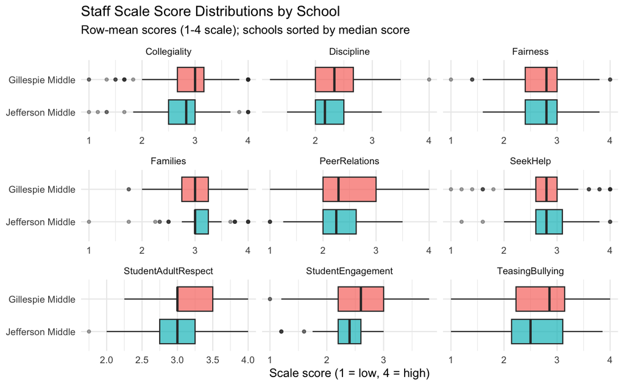

```r
mmsd_staff_scales %>%
  select(school_name, all_of(scale_cols_staff)) %>%
  filter(!is.na(school_name)) %>%
  pivot_longer(all_of(scale_cols_staff), names_to = "scale", values_to = "score") %>%
  mutate(scale = str_remove(scale, "_mean")) %>%
  ggplot(aes(x = fct_reorder(school_name, score, .fun = median, na.rm = TRUE),
             y = score, fill = school_name)) +
  geom_boxplot(alpha = 0.7, outlier.size = 1, outlier.alpha = 0.4) +
  facet_wrap(~ scale, ncol = 3, scales = "free_x") +
  coord_flip() +
  labs(
    title    = "Staff Scale Score Distributions by School",
    subtitle = "Row-mean scores (1-4 scale); schools sorted by median score",
    x        = NULL,
    y        = "Scale score (1 = low, 4 = high)"
  ) +
  theme_minimal(base_size = 10) +
  theme(legend.position = "none",
        axis.text.y     = element_text(size = 8))
```

## 20.5 Climate Profile Plot: Staff Perceptions by School

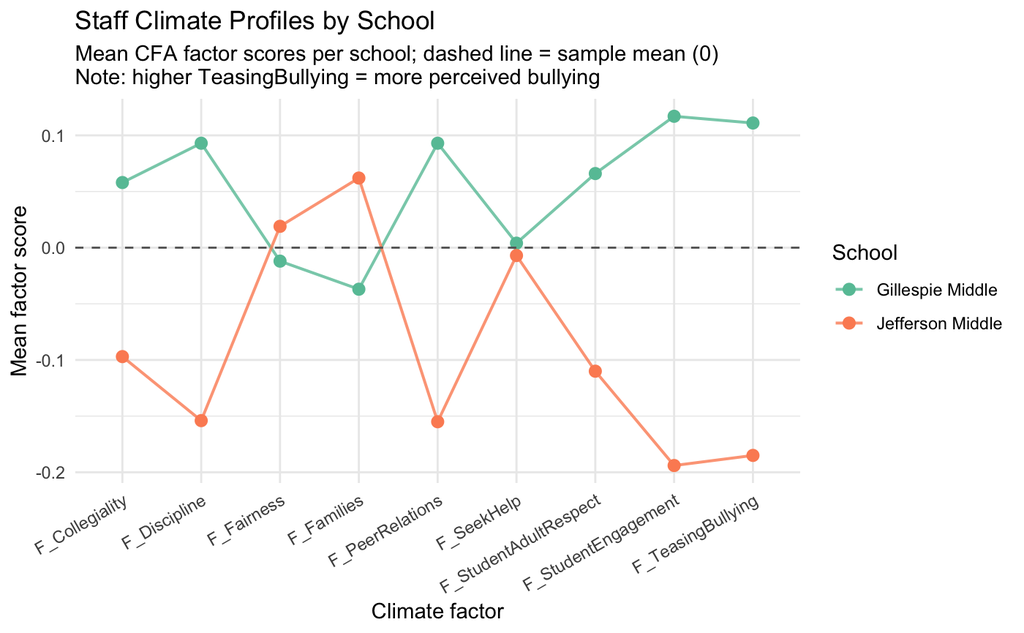

```r
profile_long <- school_means %>%
  select(school_name, factor, mean)

ggplot(profile_long, aes(x = factor, y = mean,
                          color = school_name, group = school_name)) +
  geom_point(size = 2.5) +
  geom_line(linewidth = 0.7, alpha = 0.8) +
  geom_hline(yintercept = 0, linetype = "dashed", color = "gray40", linewidth = 0.5) +
  scale_color_brewer(palette = "Set2") +
  labs(
    title    = "Staff Climate Profiles by School",
    subtitle = "Mean CFA factor scores per school; dashed line = sample mean (0)\nNote: higher TeasingBullying = more perceived bullying",
    x        = "Climate factor",
    y        = "Mean factor score",
    color    = "School"
  ) +
  theme_minimal(base_size = 11) +
  theme(axis.text.x = element_text(angle = 30, hjust = 1))
```

**Interpretation.** The profile plot reveals each school’s overall climate signature from the staff perspective. Schools whose lines consistently track above zero across the positive-valence factors (and below zero on TeasingBullying) have the most favorable staff-reported climate profiles. Schools with inconsistent profiles – high on some dimensions but low on others – point to more specific areas of concern. Comparing these staff profiles to the analogous student profile plots in the Students Rmd is one of the most valuable descriptive exercises available from this dataset: where staff and student profiles align, there is convergent evidence about the true climate; where they diverge, the discrepancy itself is an important finding.

## 20.6 Summary Table for Reporting

```r
reporting_table_staff <- mmsd_staff_scales %>%
  select(school_name, all_of(scale_cols_staff)) %>%
  pivot_longer(all_of(scale_cols_staff), names_to = "scale", values_to = "score") %>%
  mutate(scale = str_remove(scale, "_mean")) %>%
  group_by(scale) %>%
  summarise(
    overall_n       = sum(!is.na(score)),
    overall_mean    = round(mean(score, na.rm = TRUE), 2),
    overall_sd      = round(sd(score, na.rm = TRUE), 2),
    school_min_mean = round(min(
      tapply(score, school_name, mean, na.rm = TRUE), na.rm = TRUE), 2),
    school_max_mean = round(max(
      tapply(score, school_name, mean, na.rm = TRUE), na.rm = TRUE), 2),
    .groups = "drop"
  ) %>%
  mutate(school_mean_range = paste0("[", school_min_mean, ", ", school_max_mean, "]")) %>%
  select(scale, overall_n, overall_mean, overall_sd, school_mean_range) %>%
  arrange(desc(overall_mean))

cat("Summary table for reporting (row-mean scores, 1-4 scale):\n")
```

```
Summary table for reporting (row-mean scores, 1-4 scale):
```

```r
reporting_table_staff
```

| scale | overall_n | overall_mean | overall_sd | school_mean_range |
| --- | --- | --- | --- | --- |
| StudentAdultRespect | 177 | 3.19 | 0.49 | [2.99, 3.24] |
| Families | 220 | 3.05 | 0.46 | [3.01, 3.1] |
| SeekHelp | 221 | 2.85 | 0.52 | [2.84, 2.87] |
| Collegiality | 219 | 2.84 | 0.64 | [2.79, 2.87] |
| Fairness | 217 | 2.71 | 0.55 | [2.7, 2.72] |
| TeasingBullying | 213 | 2.68 | 0.69 | [2.55, 2.76] |
| StudentEngagement | 214 | 2.45 | 0.50 | [2.35, 2.51] |
| PeerRelations | 217 | 2.34 | 0.57 | [2.26, 2.39] |
| Discipline | 216 | 2.32 | 0.46 | [2.26, 2.36] |

# 21 ISF Program Context: Climate Change Across School Years

> **Stage summary.** This section describes how staff climate perceptions changed across the three data collection years: 2022–23 (pre-program baseline), 2023–24, and 2024–25 (ISF implementation years). All comparisons are purely descriptive. A key note for interpretation: the TeasingBullying factor is **negatively valenced** – higher scores mean more perceived bullying. For all other factors, higher scores indicate more positive climate perceptions. An upward trend on TeasingBullying is therefore a negative signal, while a downward trend is positive.

```r
# ============================================================
# Label school years relative to ISF program onset
# ============================================================

isf_year_labels <- c(
  "2022-2023" = "2022-23 (Pre-ISF)",
  "2023-2024" = "2023-24 (Year 1)",
  "2024-2025" = "2024-25 (Year 2)"
)

cfa_data_scored <- cfa_data_scored %>%
  mutate(
    year_label = recode(school_year, !!!isf_year_labels),
    year_label = factor(year_label, levels = isf_year_labels)
  )
```

## 21.1 Overall Staff Climate Trends Across School Years

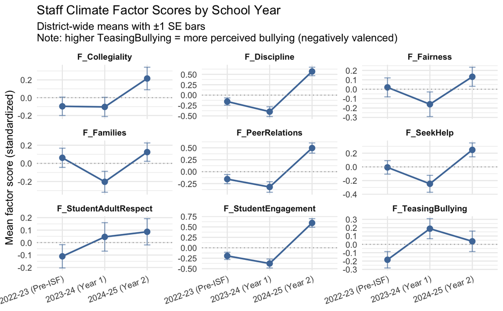

```r
year_order <- c("2022-23 (Pre-ISF)", "2023-24 (Year 1)", "2024-25 (Year 2)")

year_means <- cfa_data_scored %>%
  select(year_label, all_of(factor_names)) %>%
  pivot_longer(all_of(factor_names), names_to = "factor", values_to = "score") %>%
  group_by(factor, year_label) %>%
  summarise(
    n    = sum(!is.na(score)),
    mean = mean(score, na.rm = TRUE),
    se   = sd(score, na.rm = TRUE) / sqrt(sum(!is.na(score))),
    .groups = "drop"
  ) %>%
  mutate(year_label = factor(year_label, levels = year_order))

ggplot(year_means, aes(x = year_label, y = mean, group = 1)) +
  geom_point(size = 2.5, color = "#4e79a7") +
  geom_line(linewidth = 0.8, color = "#4e79a7") +
  geom_errorbar(
    aes(ymin = mean - se, ymax = mean + se),
    width = 0.15,
    linewidth = 0.5,
    alpha = 0.6,
    color = "#4e79a7"
  ) +
  geom_hline(
    yintercept = 0,
    linetype = "dotted",
    color = "gray60",
    linewidth = 0.4
  ) +
  facet_wrap(~ factor, scales = "free_y") +
  labs(
    title    = "Staff Climate Factor Scores by School Year",
    subtitle = "District-wide means with ±1 SE bars\nNote: higher TeasingBullying = more perceived bullying (negatively valenced)",
    x        = NULL,
    y        = "Mean factor score (standardized)"
  ) +
  theme_minimal(base_size = 11) +
  theme(
    axis.text.x = element_text(angle = 20, hjust = 1),
    strip.text = element_text(face = "bold")
  )
```

```r
year_means %>%
  select(factor, year_label, n, mean) %>%
  mutate(mean = round(mean, 3)) %>%
  pivot_wider(names_from = year_label, values_from = c(mean, n)) %>%
  mutate(
    change_yr1 = round(.[[paste0("mean_", isf_year_labels[2])]] -
                       .[[paste0("mean_", isf_year_labels[1])]], 3),
    change_yr2 = round(.[[paste0("mean_", isf_year_labels[3])]] -
                       .[[paste0("mean_", isf_year_labels[1])]], 3)
  ) %>%
  rename(
    `Change (Pre to Yr1)` = change_yr1,
    `Change (Pre to Yr2)` = change_yr2
  ) %>%
  arrange(factor)
```

| factor | mean_2022-23 (Pre-ISF) | mean_2023-24 (Year 1) | mean_2024-25 (Year 2) | n_2022-23 (Pre-ISF) | n_2023-24 (Year 1) | n_2024-25 (Year 2) | Change (Pre to Yr1) | Change (Pre to Yr2) |
| --- | --- | --- | --- | --- | --- | --- | --- | --- |
| F_Collegiality | -0.097 | -0.104 | 0.215 | 83 | 68 | 70 | -0.007 | 0.312 |
| F_Discipline | -0.154 | -0.397 | 0.569 | 83 | 68 | 70 | -0.243 | 0.723 |
| F_Fairness | 0.019 | -0.160 | 0.132 | 83 | 68 | 70 | -0.179 | 0.113 |
| F_Families | 0.062 | -0.203 | 0.124 | 83 | 68 | 70 | -0.265 | 0.062 |
| F_PeerRelations | -0.155 | -0.320 | 0.495 | 83 | 68 | 70 | -0.165 | 0.650 |
| F_SeekHelp | -0.007 | -0.247 | 0.248 | 83 | 68 | 70 | -0.240 | 0.255 |
| F_StudentAdultRespect | -0.110 | 0.046 | 0.086 | 83 | 68 | 70 | 0.156 | 0.196 |
| F_StudentEngagement | -0.194 | -0.376 | 0.595 | 83 | 68 | 70 | -0.182 | 0.789 |
| F_TeasingBullying | -0.185 | 0.188 | 0.036 | 83 | 68 | 70 | 0.373 | 0.221 |

**Interpretation.** The change columns show each factor’s shift from the 2022–23 baseline. For TeasingBullying, negative change values indicate improvement (less perceived bullying); for all other factors, positive change values indicate improvement. These are unadjusted descriptive differences that do not control for staff turnover, changes in school composition, or other concurrent programs. They characterize the program context rather than estimate program impact.

## 21.2 Staff Climate Trends by School and Year

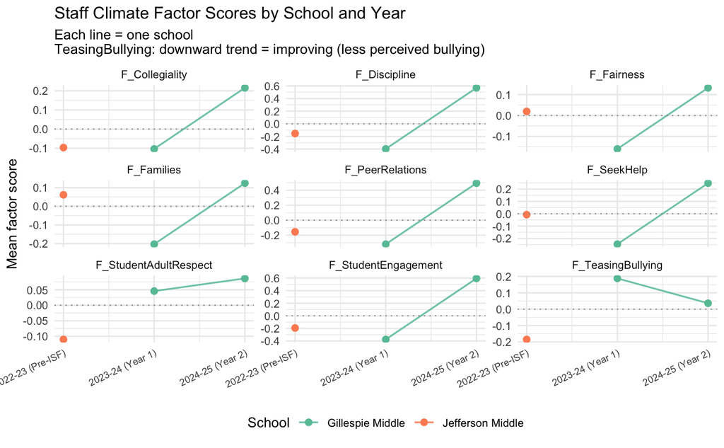

```r
school_year_means <- cfa_data_scored %>%
  select(school_name, year_label, all_of(factor_names)) %>%
  filter(!is.na(school_name)) %>%
  pivot_longer(all_of(factor_names), names_to = "factor", values_to = "score") %>%
  group_by(school_name, factor, year_label) %>%
  summarise(
    n    = sum(!is.na(score)),
    mean = mean(score, na.rm = TRUE),
    .groups = "drop"
  ) %>%
  mutate(
    year_label = factor(year_label, levels = isf_year_labels),
    x = match(as.character(year_label), isf_year_labels)
  )

ggplot(school_year_means, aes(x = x, y = mean, color = school_name, group = school_name)) +
  geom_point(size = 2) +
  geom_line(linewidth = 0.6, alpha = 0.85) +
  geom_hline(yintercept = 0, linetype = "dotted",
             color = "gray60", linewidth = 0.4) +
  facet_wrap(~ factor, ncol = 3, scales = "free_y") +
  scale_x_continuous(breaks = c(1, 2, 3), labels = isf_year_labels) +
  scale_color_brewer(palette = "Set2") +
  labs(
    title    = "Staff Climate Factor Scores by School and Year",
    subtitle = "Each line = one school
TeasingBullying: downward trend = improving (less perceived bullying)",
    x        = NULL,
    y        = "Mean factor score",
    color    = "School"
  ) +
  theme_minimal(base_size = 10) +
  theme(
    axis.text.x     = element_text(angle = 25, hjust = 1, size = 7),
    legend.position = "bottom"
  )
```

```r
baseline_label <- isf_year_labels[1]

baseline_means <- school_year_means %>%
  filter(year_label == baseline_label) %>%
  select(school_name, factor, baseline_mean = mean)

change_table <- school_year_means %>%
  filter(year_label != baseline_label) %>%
  left_join(baseline_means, by = c("school_name", "factor")) %>%
  mutate(change = round(mean - baseline_mean, 3)) %>%
  select(school_name, factor, year_label, n, mean, baseline_mean, change)

cat("Pre-to-post change in staff factor scores by school and year:\n")
```

```
Pre-to-post change in staff factor scores by school and year:
```

```r
change_table %>%
  select(school_name, factor, year_label, change) %>%
  pivot_wider(names_from = year_label, values_from = change) %>%
  arrange(school_name, factor)
```

| school_name | factor | 2023-24 (Year 1) | 2024-25 (Year 2) |
| --- | --- | --- | --- |
| Gillespie Middle | F_Collegiality | NA | NA |
| Gillespie Middle | F_Discipline | NA | NA |
| Gillespie Middle | F_Fairness | NA | NA |
| Gillespie Middle | F_Families | NA | NA |
| Gillespie Middle | F_PeerRelations | NA | NA |
| Gillespie Middle | F_SeekHelp | NA | NA |
| Gillespie Middle | F_StudentAdultRespect | NA | NA |
| Gillespie Middle | F_StudentEngagement | NA | NA |
| Gillespie Middle | F_TeasingBullying | NA | NA |

# 22 Export

```r
# Update paths to match your local environment
staff_analysis_final <- mmsd_staff_scales %>%
  left_join(
    cfa_data_scored %>%
      select(staff_id, school_year, year, iteration, school_name,
             all_of(factor_names)),
    by = c("staff_id", "school_year", "year", "iteration", "school_name")
  )

write.csv(staff_analysis_final,
          "mmsd_staff_climate_final_scored.csv",
          row.names = FALSE)

write.csv(std_final,
          "mmsd_staff_final_loadings.csv",
          row.names = FALSE)
```